# Project: Investigating Pakistan's World Development Index Dataset

## Introduction

In this Project, we will use World Development Index Dataset to analyze Pakistan's Social and Economic Indicators and will develop a model using sikit-learn to predict Pakistan's GDP based on different indicators. Provided dataset contains data about 1429 Indicator's from 1960 to 2019. We will try to answer following questions

1. How Military Expenditures of Pakistan have increased as compared to increased in GDP of Pakistan.
2. Does increase in population of Pakistan has any impact on its Inflation Rate.
3. Whether Pakistan has been able to control his government expenditures.
- Develop a model to predict GDP of Pakistan.

## Data Wrangling

```python
import numpy as np
import pandas as pd
import matplotlib.pyplot as plt
%matplotlib inline
df = pd.read_csv('./pak_wdi.csv')
#df.head()
```

```python
df.head()
```

|  | Country Name | Country Code | Indicator Name | Indicator Code | 1960 | 1961 | 1962 | 1963 | 1964 | 1965 | ... | 2010 | 2011 | 2012 | 2013 | 2014 | 2015 | 2016 | 2017 | 2018 | 2019 |
| --- | --- | --- | --- | --- | --- | --- | --- | --- | --- | --- | --- | --- | --- | --- | --- | --- | --- | --- | --- | --- | --- |
| 0 | Pakistan | PAK | Access to clean fuels and technologies for coo... | EG.CFT.ACCS.ZS | NaN | NaN | NaN | NaN | NaN | NaN | ... | 35.590000 | 36.850000 | 38.130000 | 39.470000 | 40.740000 | 42.130000 | 43.320000 | NaN | NaN | NaN |
| 1 | Pakistan | PAK | Access to electricity (% of population) | EG.ELC.ACCS.ZS | NaN | NaN | NaN | NaN | NaN | NaN | ... | 70.421844 | 70.507156 | 70.636093 | 70.799934 | 70.989944 | 71.197411 | 71.413597 | 70.790000 | NaN | NaN |
| 2 | Pakistan | PAK | Access to electricity, rural (% of rural popul... | EG.ELC.ACCS.RU.ZS | NaN | NaN | NaN | NaN | NaN | NaN | ... | 55.904752 | 55.680362 | 55.537024 | 55.455140 | 55.406350 | 55.369003 | 55.327793 | 54.136832 | NaN | NaN |
| 3 | Pakistan | PAK | Access to electricity, urban (% of urban popul... | EG.ELC.ACCS.UR.ZS | NaN | NaN | NaN | NaN | NaN | NaN | ... | 97.263245 | 97.679604 | 98.106613 | 98.542152 | 98.984085 | 99.430283 | 99.878609 | 100.000000 | NaN | NaN |
| 4 | Pakistan | PAK | Account ownership at a financial institution o... | FX.OWN.TOTL.ZS | NaN | NaN | NaN | NaN | NaN | NaN | ... | NaN | 10.306296 | NaN | NaN | 13.036192 | NaN | NaN | 21.293245 | NaN | NaN |

5 rows × 64 columns

```python
df.describe()
```

|  | 1960 | 1961 | 1962 | 1963 | 1964 | 1965 | 1966 | 1967 | 1968 | 1969 | ... | 2010 | 2011 | 2012 | 2013 | 2014 | 2015 | 2016 | 2017 | 2018 | 2019 |
| --- | --- | --- | --- | --- | --- | --- | --- | --- | --- | --- | --- | --- | --- | --- | --- | --- | --- | --- | --- | --- | --- |
| count | 2.320000e+02 | 2.610000e+02 | 2.750000e+02 | 2.760000e+02 | 2.790000e+02 | 2.860000e+02 | 2.790000e+02 | 3.170000e+02 | 3.120000e+02 | 3.220000e+02 | ... | 1.024000e+03 | 1.050000e+03 | 9.460000e+02 | 1.116000e+03 | 1.018000e+03 | 1.007000e+03 | 9.440000e+02 | 9.000000e+02 | 8.580000e+02 | 9.700000e+01 |
| mean | 1.341319e+10 | 1.318002e+10 | 1.316783e+10 | 1.463868e+10 | 1.562519e+10 | 1.703667e+10 | 1.761848e+10 | 2.252476e+10 | 2.520858e+10 | 2.406562e+10 | ... | 2.326219e+11 | 2.600577e+11 | 3.133202e+11 | 2.900950e+11 | 3.496730e+11 | 3.814271e+11 | 4.332618e+11 | 4.950111e+11 | 5.594067e+11 | 7.625210e+05 |
| std | 7.458533e+10 | 7.541963e+10 | 7.688848e+10 | 8.469973e+10 | 9.020762e+10 | 9.923469e+10 | 1.033659e+11 | 1.263570e+11 | 1.391329e+11 | 1.382805e+11 | ... | 1.470934e+12 | 1.713776e+12 | 1.980968e+12 | 2.012591e+12 | 2.337516e+12 | 2.545308e+12 | 2.800532e+12 | 3.152987e+12 | 3.514789e+12 | 7.507847e+06 |
| min | -3.080262e+09 | -3.967181e+00 | -3.896715e+09 | -7.964147e+09 | -8.906782e+09 | -1.013889e+10 | -3.107727e+10 | -4.342059e+09 | -2.161902e+09 | -2.138094e+09 | ... | -8.680000e+11 | -9.150000e+11 | -1.610000e+12 | -1.520000e+12 | -1.610000e+12 | -1.770000e+12 | -2.040000e+12 | -2.980000e+12 | -3.790000e+12 | 0.000000e+00 |
| 25% | 6.923738e+00 | 6.245240e+00 | 6.295790e+00 | 7.493638e+00 | 7.376509e+00 | 7.215266e+00 | 6.197558e+00 | 6.600000e+00 | 6.709417e+00 | 6.414378e+00 | ... | 4.795989e+00 | 6.016262e+00 | 5.574470e+00 | 6.094127e+00 | 6.329637e+00 | 7.162286e+00 | 7.230652e+00 | 6.948585e+00 | 7.559050e+00 | 9.009000e+00 |
| 50% | 7.758570e+01 | 5.434289e+01 | 4.720400e+01 | 4.784150e+01 | 4.859600e+01 | 4.938850e+01 | 4.742807e+01 | 6.349020e+01 | 7.359562e+01 | 7.537400e+01 | ... | 4.265078e+01 | 4.191030e+01 | 5.000000e+01 | 3.738466e+01 | 4.570000e+01 | 4.734500e+01 | 4.953983e+01 | 5.108753e+01 | 4.596367e+01 | 2.860800e+01 |
| 75% | 2.537875e+08 | 2.075300e+08 | 4.182977e+07 | 3.844544e+07 | 3.464311e+07 | 3.253750e+07 | 3.197000e+07 | 1.824864e+08 | 3.798076e+08 | 3.191300e+08 | ... | 3.864362e+05 | 6.992650e+04 | 6.634423e+05 | 5.014117e+03 | 1.765746e+05 | 4.628955e+05 | 1.743664e+06 | 2.452458e+06 | 6.212342e+05 | 6.095491e+01 |
| max | 7.060000e+11 | 7.480000e+11 | 7.820000e+11 | 8.500000e+11 | 9.140000e+11 | 1.010000e+12 | 1.070000e+12 | 1.310000e+12 | 1.470000e+12 | 1.470000e+12 | ... | 1.570000e+13 | 1.920000e+13 | 2.170000e+13 | 2.390000e+13 | 2.680000e+13 | 2.920000e+13 | 3.110000e+13 | 3.490000e+13 | 3.840000e+13 | 7.394393e+07 |

8 rows × 60 columns

```python
df.isna()
```

|  | Country Name | Country Code | Indicator Name | Indicator Code | 1960 | 1961 | 1962 | 1963 | 1964 | 1965 | ... | 2010 | 2011 | 2012 | 2013 | 2014 | 2015 | 2016 | 2017 | 2018 | 2019 |
| --- | --- | --- | --- | --- | --- | --- | --- | --- | --- | --- | --- | --- | --- | --- | --- | --- | --- | --- | --- | --- | --- |
| 0 | False | False | False | False | True | True | True | True | True | True | ... | False | False | False | False | False | False | False | True | True | True |
| 1 | False | False | False | False | True | True | True | True | True | True | ... | False | False | False | False | False | False | False | False | True | True |
| 2 | False | False | False | False | True | True | True | True | True | True | ... | False | False | False | False | False | False | False | False | True | True |
| 3 | False | False | False | False | True | True | True | True | True | True | ... | False | False | False | False | False | False | False | False | True | True |
| 4 | False | False | False | False | True | True | True | True | True | True | ... | True | False | True | True | False | True | True | False | True | True |
| ... | ... | ... | ... | ... | ... | ... | ... | ... | ... | ... | ... | ... | ... | ... | ... | ... | ... | ... | ... | ... | ... |
| 1424 | False | False | False | False | True | True | True | True | True | True | ... | True | True | True | False | True | True | True | True | False | True |
| 1425 | False | False | False | False | True | True | True | True | True | True | ... | True | True | True | False | True | True | True | True | False | True |
| 1426 | False | False | False | False | True | True | True | True | True | True | ... | True | True | True | False | True | True | True | True | False | True |
| 1427 | False | False | False | False | True | True | True | True | True | True | ... | True | True | True | False | True | True | True | True | False | True |
| 1428 | False | False | False | False | True | True | True | True | True | True | ... | False | False | False | False | False | False | False | False | False | True |

1429 rows × 64 columns

## Cleaning Data

### In Below column, we delete Country Name and Code as it is repeatedly being used in the data. Then we take transpose so that data is properly formatted

```python
del df['Country Name']
del df['Country Code']
df_trans=df.T
df_trans.head()
```

|  | 0 | 1 | 2 | 3 | 4 | 5 | 6 | 7 | 8 | 9 | ... | 1419 | 1420 | 1421 | 1422 | 1423 | 1424 | 1425 | 1426 | 1427 | 1428 |
| --- | --- | --- | --- | --- | --- | --- | --- | --- | --- | --- | --- | --- | --- | --- | --- | --- | --- | --- | --- | --- | --- |
| Indicator Name | Access to clean fuels and technologies for coo... | Access to electricity (% of population) | Access to electricity, rural (% of rural popul... | Access to electricity, urban (% of urban popul... | Account ownership at a financial institution o... | Account ownership at a financial institution o... | Account ownership at a financial institution o... | Account ownership at a financial institution o... | Account ownership at a financial institution o... | Account ownership at a financial institution o... | ... | Women participating in the three decisions (ow... | Women who believe a husband is justified in be... | Women who believe a husband is justified in be... | Women who believe a husband is justified in be... | Women who believe a husband is justified in be... | Women who believe a husband is justified in be... | Women who believe a husband is justified in be... | Women who were first married by age 15 (% of w... | Women who were first married by age 18 (% of w... | Women's share of population ages 15+ living wi... |
| Indicator Code | EG.CFT.ACCS.ZS | EG.ELC.ACCS.ZS | EG.ELC.ACCS.RU.ZS | EG.ELC.ACCS.UR.ZS | FX.OWN.TOTL.ZS | FX.OWN.TOTL.FE.ZS | FX.OWN.TOTL.MA.ZS | FX.OWN.TOTL.OL.ZS | FX.OWN.TOTL.40.ZS | FX.OWN.TOTL.PL.ZS | ... | SG.DMK.ALLD.FN.ZS | SG.VAW.REAS.ZS | SG.VAW.ARGU.ZS | SG.VAW.BURN.ZS | SG.VAW.GOES.ZS | SG.VAW.NEGL.ZS | SG.VAW.REFU.ZS | SP.M15.2024.FE.ZS | SP.M18.2024.FE.ZS | SH.DYN.AIDS.FE.ZS |
| 1960 | NaN | NaN | NaN | NaN | NaN | NaN | NaN | NaN | NaN | NaN | ... | NaN | NaN | NaN | NaN | NaN | NaN | NaN | NaN | NaN | NaN |
| 1961 | NaN | NaN | NaN | NaN | NaN | NaN | NaN | NaN | NaN | NaN | ... | NaN | NaN | NaN | NaN | NaN | NaN | NaN | NaN | NaN | NaN |
| 1962 | NaN | NaN | NaN | NaN | NaN | NaN | NaN | NaN | NaN | NaN | ... | NaN | NaN | NaN | NaN | NaN | NaN | NaN | NaN | NaN | NaN |

5 rows × 1429 columns

```python
num_rows = df_trans.shape[0] #Provide the number of rows in the dataset
num_cols = df_trans.shape[1] #Provide the number of columns in the dataset
print("Rows = ",num_rows)
print("Columns = ",num_cols)
```

```
Rows =  62
Columns =  1429
```

### We use loop to get all indicators from the dataset and store it in a list

```python
cols_list=[]
for name in range(num_cols):
    #print(df_trans[name][0])
    cols_list.append(df_trans[name][0])
```

```python
df_trans.columns = cols_list ##Column names changed to indicator name
df_trans.head()
```

|  | Access to clean fuels and technologies for cooking (% of population) | Access to electricity (% of population) | Access to electricity, rural (% of rural population) | Access to electricity, urban (% of urban population) | Account ownership at a financial institution or with a mobile-money-service provider (% of population ages 15+) | Account ownership at a financial institution or with a mobile-money-service provider, female (% of population ages 15+) | Account ownership at a financial institution or with a mobile-money-service provider, male (% of population ages 15+) | Account ownership at a financial institution or with a mobile-money-service provider, older adults (% of population ages 25+) | Account ownership at a financial institution or with a mobile-money-service provider, poorest 40% (% of population ages 15+) | Account ownership at a financial institution or with a mobile-money-service provider, primary education or less (% of population ages 15+) | ... | Women participating in the three decisions (own health care, major household purchases, and visiting family) (% of women age 15-49) | Women who believe a husband is justified in beating his wife (any of five reasons) (%) | Women who believe a husband is justified in beating his wife when she argues with him (%) | Women who believe a husband is justified in beating his wife when she burns the food (%) | Women who believe a husband is justified in beating his wife when she goes out without telling him (%) | Women who believe a husband is justified in beating his wife when she neglects the children (%) | Women who believe a husband is justified in beating his wife when she refuses sex with him (%) | Women who were first married by age 15 (% of women ages 20-24) | Women who were first married by age 18 (% of women ages 20-24) | Women's share of population ages 15+ living with HIV (%) |
| --- | --- | --- | --- | --- | --- | --- | --- | --- | --- | --- | --- | --- | --- | --- | --- | --- | --- | --- | --- | --- | --- |
| Indicator Name | Access to clean fuels and technologies for coo... | Access to electricity (% of population) | Access to electricity, rural (% of rural popul... | Access to electricity, urban (% of urban popul... | Account ownership at a financial institution o... | Account ownership at a financial institution o... | Account ownership at a financial institution o... | Account ownership at a financial institution o... | Account ownership at a financial institution o... | Account ownership at a financial institution o... | ... | Women participating in the three decisions (ow... | Women who believe a husband is justified in be... | Women who believe a husband is justified in be... | Women who believe a husband is justified in be... | Women who believe a husband is justified in be... | Women who believe a husband is justified in be... | Women who believe a husband is justified in be... | Women who were first married by age 15 (% of w... | Women who were first married by age 18 (% of w... | Women's share of population ages 15+ living wi... |
| Indicator Code | EG.CFT.ACCS.ZS | EG.ELC.ACCS.ZS | EG.ELC.ACCS.RU.ZS | EG.ELC.ACCS.UR.ZS | FX.OWN.TOTL.ZS | FX.OWN.TOTL.FE.ZS | FX.OWN.TOTL.MA.ZS | FX.OWN.TOTL.OL.ZS | FX.OWN.TOTL.40.ZS | FX.OWN.TOTL.PL.ZS | ... | SG.DMK.ALLD.FN.ZS | SG.VAW.REAS.ZS | SG.VAW.ARGU.ZS | SG.VAW.BURN.ZS | SG.VAW.GOES.ZS | SG.VAW.NEGL.ZS | SG.VAW.REFU.ZS | SP.M15.2024.FE.ZS | SP.M18.2024.FE.ZS | SH.DYN.AIDS.FE.ZS |
| 1960 | NaN | NaN | NaN | NaN | NaN | NaN | NaN | NaN | NaN | NaN | ... | NaN | NaN | NaN | NaN | NaN | NaN | NaN | NaN | NaN | NaN |
| 1961 | NaN | NaN | NaN | NaN | NaN | NaN | NaN | NaN | NaN | NaN | ... | NaN | NaN | NaN | NaN | NaN | NaN | NaN | NaN | NaN | NaN |
| 1962 | NaN | NaN | NaN | NaN | NaN | NaN | NaN | NaN | NaN | NaN | ... | NaN | NaN | NaN | NaN | NaN | NaN | NaN | NaN | NaN | NaN |

5 rows × 1429 columns

### Exploratory Data Analysis

```python
cleaned_data = df_trans.drop(["Indicator Name", "Indicator Code"], axis=0) #Deleting extra row of Indicator and Indicator Code
cleaned_data.head()
```

|  | Access to clean fuels and technologies for cooking (% of population) | Access to electricity (% of population) | Access to electricity, rural (% of rural population) | Access to electricity, urban (% of urban population) | Account ownership at a financial institution or with a mobile-money-service provider (% of population ages 15+) | Account ownership at a financial institution or with a mobile-money-service provider, female (% of population ages 15+) | Account ownership at a financial institution or with a mobile-money-service provider, male (% of population ages 15+) | Account ownership at a financial institution or with a mobile-money-service provider, older adults (% of population ages 25+) | Account ownership at a financial institution or with a mobile-money-service provider, poorest 40% (% of population ages 15+) | Account ownership at a financial institution or with a mobile-money-service provider, primary education or less (% of population ages 15+) | ... | Women participating in the three decisions (own health care, major household purchases, and visiting family) (% of women age 15-49) | Women who believe a husband is justified in beating his wife (any of five reasons) (%) | Women who believe a husband is justified in beating his wife when she argues with him (%) | Women who believe a husband is justified in beating his wife when she burns the food (%) | Women who believe a husband is justified in beating his wife when she goes out without telling him (%) | Women who believe a husband is justified in beating his wife when she neglects the children (%) | Women who believe a husband is justified in beating his wife when she refuses sex with him (%) | Women who were first married by age 15 (% of women ages 20-24) | Women who were first married by age 18 (% of women ages 20-24) | Women's share of population ages 15+ living with HIV (%) |
| --- | --- | --- | --- | --- | --- | --- | --- | --- | --- | --- | --- | --- | --- | --- | --- | --- | --- | --- | --- | --- | --- |
| 1960 | NaN | NaN | NaN | NaN | NaN | NaN | NaN | NaN | NaN | NaN | ... | NaN | NaN | NaN | NaN | NaN | NaN | NaN | NaN | NaN | NaN |
| 1961 | NaN | NaN | NaN | NaN | NaN | NaN | NaN | NaN | NaN | NaN | ... | NaN | NaN | NaN | NaN | NaN | NaN | NaN | NaN | NaN | NaN |
| 1962 | NaN | NaN | NaN | NaN | NaN | NaN | NaN | NaN | NaN | NaN | ... | NaN | NaN | NaN | NaN | NaN | NaN | NaN | NaN | NaN | NaN |
| 1963 | NaN | NaN | NaN | NaN | NaN | NaN | NaN | NaN | NaN | NaN | ... | NaN | NaN | NaN | NaN | NaN | NaN | NaN | NaN | NaN | NaN |
| 1964 | NaN | NaN | NaN | NaN | NaN | NaN | NaN | NaN | NaN | NaN | ... | NaN | NaN | NaN | NaN | NaN | NaN | NaN | NaN | NaN | NaN |

5 rows × 1429 columns

## Modeling Data

```python
import numpy as np
import pandas as pd
import matplotlib.pyplot as plt
from matplotlib.pyplot import figure
from sklearn.metrics import accuracy_score
from sklearn.linear_model import LinearRegression
from sklearn.model_selection import train_test_split
from sklearn.metrics import r2_score, mean_squared_error
import seaborn as sns
%matplotlib inline
```

```python
X = cleaned_data[['Exports of goods and services (current US$)', 'Gross national expenditure (current US$)', 'Gross savings (current US$)', 'Imports of goods and services (current US$)','Military expenditure (current USD)','Personal remittances, received (current US$)']]
y = cleaned_data['GDP (current US$)']
#Getting dimensions of both data sets
print(cleaned_y.shape)
print(cleaned_X.shape)
cleaned_y = cleaned_y.head(43) #Equalizing first dimensions of X and Y data
print(cleaned_y.shape)
print(cleaned_X.shape)
X_train, X_test, y_train, y_test = train_test_split(cleaned_X, cleaned_y, test_size=.15, random_state=50)
lm_model =LinearRegression(normalize=True)
lm_model.fit(X_train, y_train)
```

[output not shown]

```
LinearRegression(copy_X=True, fit_intercept=True, n_jobs=None, normalize=True)
```

## Question 1 - How much Military Expenditures cost to GDP of Pakistan

```python
mil_data=cleaned_data['Military expenditure (current USD)'].tolist()
gdp_data=cleaned_data['GDP (current US$)'].tolist()
```

```python
indexNamesArr = cleaned_data.index.values
row_labels = list(indexNamesArr) #Getting list of all years which are Row-Labels right now
```

```python
def double_plotting(first_data, second_data,x_label,y_label,title):
    '''
    This function plots 2 Dataframes in one Graph

    INPUT

    first_data - First Dataframe
    second_data - Second Dataframe
    x_label - Label of X-Axis
    y_label - Label of Y-Axis
    title - Title of the Plot

    OUTPUT

    Plot containing 2 dataframes
    '''
    plt.plot(row_labels, first_data)
    plt.plot(row_labels, second_data)
    ax = plt.axes()
    ax.yaxis.set_major_locator(plt.NullLocator())
    ax.xaxis.set_major_formatter(plt.NullFormatter())
    plt.xlabel(x_label)
    plt.ylabel(y_label)
    plt.title(title)
```

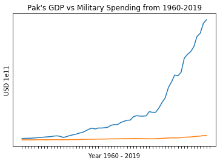

```python
double_plotting(gdp_data, mil_data, "Year 1960 - 2019", "USD 1e11", "Pak's GDP vs Military Spending from 1960-2019")
```

# Question - 2 : Is there any relationship between Population of Pakistan and Inflation Rate.

```python
population_data=cleaned_data['Population, total'].tolist()
inflation_data=cleaned_data['Inflation, consumer prices (annual %)'].tolist()
```

```python
def single_plot(first_data, second_data,x_label,y_label,title):
    plt.plot(first_data, second_data)
    #plt.plot(row_labels, inflation_data)
    ax = plt.axes()
    ax.yaxis.set_major_locator(plt.NullLocator())
    ax.xaxis.set_major_formatter(plt.NullFormatter())
    plt.xlabel(x_label)
    plt.ylabel(y_label)
    plt.title(title)
```

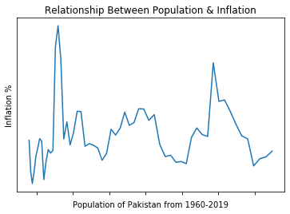

```python
single_plot(population_data, inflation_data,"Population of Pakistan from 1960-2019","Inflation %","Relationship Between Population & Inflation")
```

###### Answer - 2: From the above graph we can conclude that there is not significant relationship between Population and Inflation of Pakistan. This is because the graph is very uneven. If there was a relation between these two, then the graph should have shown relatively linear behaviour

# Question - 3 : How Government Expenditures of Pakistan have increased with increase in GDP Growth

```python
expend_data=cleaned_data['Gross national expenditure (current US$)'].tolist()
```

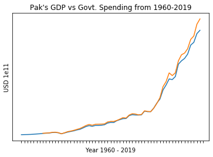

```python
double_plotting(gdp_data, expend_data, "Year 1960 - 2019", "USD 1e11", "Pak's GDP vs Govt. Spending from 1960-2019")
```

# Question 4 - Prediction of Pakistan's GDP

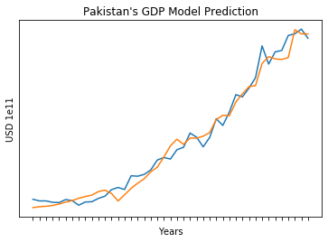

```python
prediction = lm_model.predict(cleaned_X)
prediction = pd.Series(prediction) #Coverting to plot predicted data on graph
prediction.size
plt.plot(row_labels[:43], prediction)
plt.plot(row_labels[:43], cleaned_y)
ax = plt.axes()
ax.yaxis.set_major_locator(plt.NullLocator())
ax.xaxis.set_major_formatter(plt.NullFormatter())
plt.xlabel("Years")
plt.ylabel("USD 1e11")
plt.title("Pakistan's GDP Model Prediction")
figure(num=None, figsize=(20,20), dpi=180)
```

## Submitting your Project

> Before you submit your project, you need to create a .html or .pdf version of this notebook in the workspace here. To do that, run the code cell below. If it worked correctly, you should get a return code of 0, and you should see the generated .html file in the workspace directory (click on the orange Jupyter icon in the upper left).

> Alternatively, you can download this report as .html via the **File** > **Download as** submenu, and then manually upload it into the workspace directory by clicking on the orange Jupyter icon in the upper left, then using the Upload button.

> Once you've done this, you can submit your project by clicking on the "Submit Project" button in the lower right here. This will create and submit a zip file with this .ipynb doc and the .html or .pdf version you created. Congratulations!

```python
from subprocess import call
call(['python', '-m', 'nbconvert', 'Investigate_a_Dataset.ipynb'])
```